# The Brazilian eCommerce

Author

Daniel Rabi and Jaswinder Brar

Published

June 11, 2026

# Executive Summary

Olist operates as a critical marketplace integrator in Brazil’s highly competitive e-commerce landscape, connecting small and medium merchants with major national retail channels. Operating this complex, multi-sided marketplace requires precise operational planning, lean logistical coordination, and proactive inventory management.

This report presents an analytical evaluation of Olist’s transactional ecosystem using historical platform data (olist.sqlite). We focus on two core strategic pillars:

1. **Exploratory Data Analysis (EDA):** Decoding overall trajectories and categorical revenue distributions to expose structural platform vulnerabilities.
2. **Predictive Modelling Framework:** Engineering a robust time-series regression pipeline using `tidymodels` to forecast next-week category revenue ($t+1$), giving Olist and its partner merchants a distinct logistical advantage, hence improving efficiency and profitability.

# Goal 1: Exploratory Data Analysis and Strategic Findings

## Finding 1: Olist’s purchase value grew rapidly over time, while seasonality was less clear

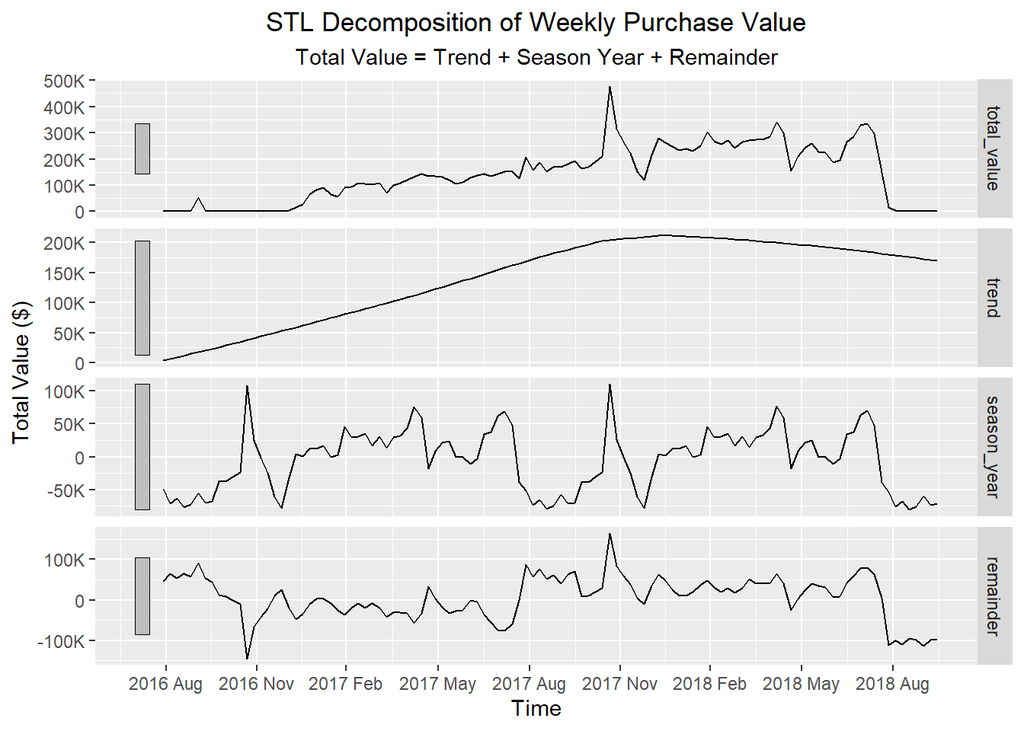

The first major finding is that Olist’s weekly purchase value increased substantially over the period under observation, suggesting strong platform growth. Although weekly purchase value fluctuated over time, the STL decomposition shows that the trend component was the dominant pattern in the data. The trend increased steadily through 2017 and reached its highest level around early 2018 before flattening near the end of the dataset.

To investigate this, we aggregated the order and payment data by purchase week and calculated the total weekly purchase value. We then applied STL decomposition to separate the time series into three components: trend, seasonal variation, and remainder. This approach helped distinguish long-term growth from repeated seasonal movement and short-term noise.

The decomposition suggests that Olist’s purchase value was more influenced by long-term market growth than by a clear seasonal cycle. The trend panel shows a strong upward movement across most of the period, while the seasonal component is smaller relative to the overall increase in purchase value and shows no clear pattern. Therefore, the main business insight is that Olist was not simply experiencing normal seasonal ups and downs; it was operating in a period of rapid expansion.

This finding matters because rapid growth creates operational pressure. If Olist treats every increase or decrease in sales as a seasonal pattern, management may miss the larger issue: the platform needs enough operational capacity to support sustained growth. Olist should therefore focus on scalable improvements such as seller onboarding, payment processing, customer support, and delivery coordination. However, because operational resources are limited, Olist should not treat all product categories equally. The next step is to identify which categories generate the most revenue so that growth planning can focus on the areas with the greatest financial impact.

## Finding 2: Revenue is concentrated in a small number of product categories

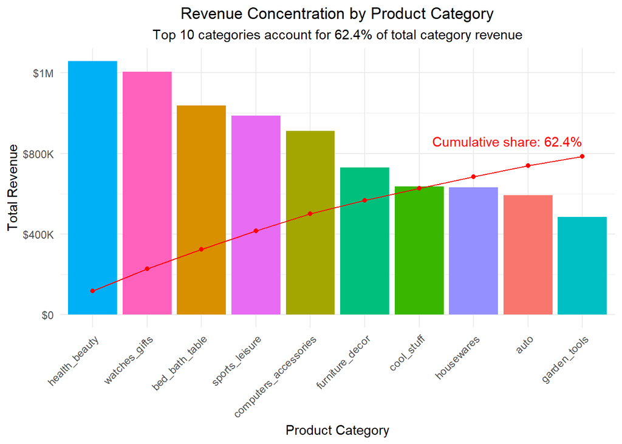

The second major finding is that Olist’s revenue is highly concentrated among a small number of product categories. Although the dataset contains 72 product categories, the top 10 categories account for 62.4% of total category revenue. This product concentration shows that Olist’s marketplace revenue is not evenly distributed across categories. Instead, a relatively small group of categories drives most of the platform’s sales.

The chart also shows a clear separation among the highest-revenue categories. Health/beauty, watches/gifts, bed/bath/table, sports/leisure, and computer accessories are the top five revenue-generating categories, and they are the only categories that exceed roughly $800,000 in total revenue. The higher revenue concentration makes the top five categories especially important from a business perspective because changes in their demand or delivery performance could have a larger effect on total revenue than changes in lower-revenue categories.

To discover this finding, we joined the product, order item, and product category translation tables. Joining the tables allowed us to connect each sold item to an English product category name and calculate total revenue by category using item prices. We then ranked product categories by revenue from highest to lowest and calculated the cumulative revenue share to measure how much total revenue was explained by the largest categories.

This finding matters because revenue concentration creates both opportunities and risks. On the opportunity side, Olist can prioritize high-revenue categories when planning seller support, promotions, inventory preparation, and delivery coordination. Improving performance in these categories is likely to have a meaningful impact on overall revenue. However, concentration also increases risk. If one of the major categories experiences stock shortages, delayed deliveries, or lower customer satisfaction, Olist’s overall revenue performance could be affected.

This finding also supports the prediction objective in Goal 2. Since category-level revenue is highly uneven, forecasting next week’s revenue by product category can help Olist identify which categories are likely to drive future sales and prepare sellers and logistics partners before demand changes occur.

# Goal 2: Predicting Next-Week Revenue by Product Category

## Business Objective

The business objective for Goal 2 is to predict next week’s revenue for each product category. This prediction can help Olist improve operational efficiency by identifying which categories are expected to generate the most sales in the coming week. If Olist can anticipate category-level demand in advance, it can better coordinate with sellers, plan logistics capacity, and reduce the risk of stock shortages or delivery delays in high-revenue categories.

Next week’s prediction objective connects directly to the revenue concentration finding from Goal 1. Since a relatively small number of product categories account for a large share of total revenue, forecasting category-level revenue can help Olist focus on the categories most likely to affect overall marketplace performance.

## Data Preparation and Feature Engineering

To build the prediction dataset, we aggregated transactions by product category and purchase week. The target variable was `future_revenue`, representing next week’s revenue for the same product category. The `future_revenue` variable was created using a lead function, so each row uses current and past information to predict next week’s revenue.

Several predictors were engineered to capture category-level demand and operational conditions. These included current weekly revenue, previous week revenue, the number of active sellers, average review score, late-delivery proportion, four-week rolling average revenue, and four-week rolling revenue volatility. These prediction variables were selected because they describe both demand momentum and operational performance.

We also cleaned missing and inconsistent values before modelling. Eight orders were identified as delivered, but did not have a recorded customer delivery date. Since delivery timeliness could not be determined for these observations, they were excluded from the late-delivery analysis. Missing weekly review scores were imputed using the average review score within the corresponding product category. For category-weeks with no observed delivery records, the late-delivery proportion was set to zero. These decisions allowed us to keep the weekly category-level dataset complete while avoiding misleading late-delivery calculations.

A time-based split was used instead of a random split. The time-based approach means the data were kept in chronological order, with older observations used for training and newer observations for testing. The first 70% of the prepared dataset was used for training, and the remaining 30% was reserved for testing. Because the prepared dataset contained fewer than 10,000 observations, the 70:30 split provided enough data for model training while still leaving a meaningful test set for evaluating forecasting performance.

## Models Tested

We compared several model types to determine which approach best predicted next-week category revenue. For each model type, we tested different predictor combinations and, when applicable, adjusted model parameters to improve forecasting performance.

First, we tested linear regression models using different combinations of predictors. Linear regression was useful as a baseline model because it is easy to interpret and indicates whether revenue can be predicted by a mostly linear relationship.

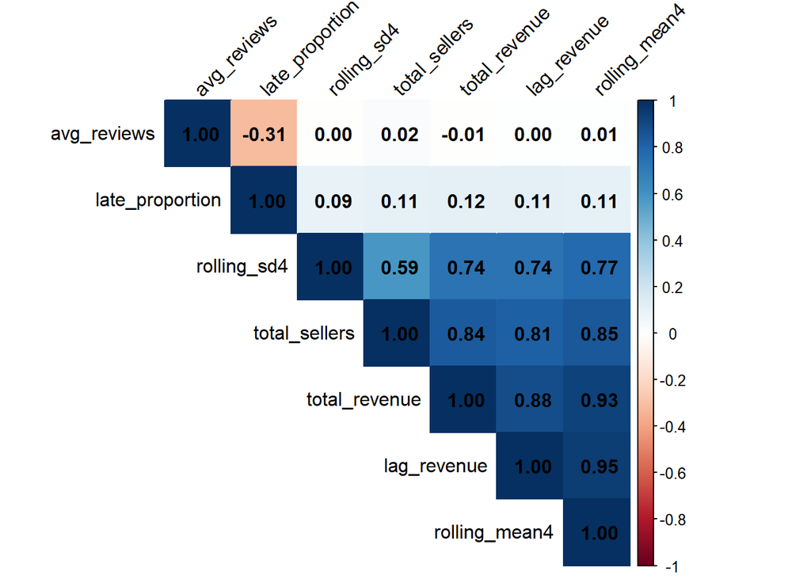

VIF Table

| Predictor | VIF |
| --- | --- |
| total_revenue | 7.797976 |
| lag_revenue | 9.470140 |
| total_sellers | 4.087960 |
| avg_reviews | 1.112398 |
| late_proportion | 1.126171 |
| rolling_sd4 | 2.645790 |
| rolling_mean4 | 16.702361 |

Second, we tested PCA-based linear regression. The correlation matrix and VIF results indicated that some predictors were strongly correlated, particularly revenue-based variables such as current revenue, lagged revenue, and rolling average revenue. PCA was used to reduce multicollinearity by transforming the original predictors into principal components. Breaking the prediction variables into principal components enabled us to test whether a lower-dimensional representation of the data could improve predictive performance.

Third, we tested regression tree models. Regression trees are useful because they can capture non-linear relationships and interactions between predictors. Unlike linear regression, they do not require the relationship between predictors and revenue to be strictly linear. The regression tree models were tuned by changing parameters such as tree depth and the minimum number of observations required in a terminal node.

Finally, we tested random forest models. Random forests improve on single decision trees by building many trees and averaging their predictions. The averaging method generally reduces overfitting and produces more stable predictions. The random forest models were tuned by changing the number of trees, the number of predictors considered at each split, and the minimum number of observations required in a terminal node.

## Model Evaluation and Selection

Final Model Comparison

Performance on the time-based testing set

| Model | Best Version | MAE | RMSE | R² |
| --- | --- | --- | --- | --- |
| Linear Regression | total_revenue + lag_revenue | 1,121.39 | 2,137.53 | 80.31% |
| PCA Linear Regression | 7 principal components | 1,086.98 | 2,161.45 | 79.82% |
| Regression Tree | tree_depth = 5, min_n = 5, cost_complexity = 0.001 | 1,168.33 | 2,128.57 | 80.46% |
| Random Forest | 500 trees, mtry = 1, min_n = 20 | 1,122.26 | 2,099.07 | 80.98% |

The models were evaluated on the testing set using RMSE, MAE, and R-squared. RMSE and MAE measure prediction error, while R-squared measures how much variation in future revenue the model explains on unseen data.

Based on the final comparison, the selected model was the best-performing random forest model. This model was then used to generate the next-week revenue forecast for each product category.

## Final Forecast and Business Implications

The final random forest model was used to forecast next-week revenue by product category. The forecasted results showed which categories are expected to generate the highest revenue in the next period. The forecasted revenue gives Olist a practical tool for short-term operational planning.

From a business perspective, the model can support three main decisions. First, Olist can use the forecast to identify high-demand categories before the demand occurs. Knowing high-demand categories in advance allows the company to communicate with sellers and encourage them to prepare sufficient inventory. Second, Olist can use the forecast to coordinate delivery capacity for categories expected to generate higher order volume. Third, management can use the forecast to monitor whether the same high-revenue categories from Goal 1 are expected to continue driving revenue in the near future.

The model should not be interpreted as a perfect prediction system. Instead, it should be used as an early warning tool. If the model predicts that a category’s revenue will increase next week, Olist can investigate whether sellers and logistics partners are prepared. If the model predicts lower revenue, Olist can avoid over-allocating resources to that category. Therefore, predicting next week’s revenue for each category helps improve efficiency while still supporting customer satisfaction.

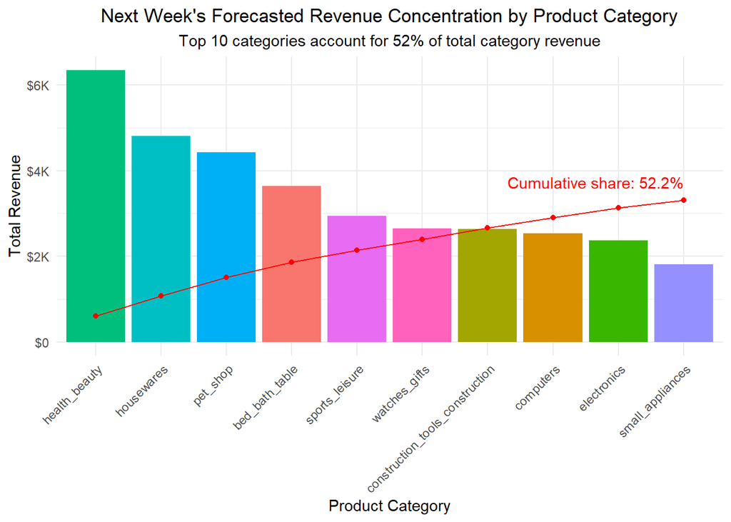

Top 10 Predicted Product Categories by Next Week Revenue

| Product Category | Latest Available Date | Next Forecasted Date | Forecasted Revenue |
| --- | --- | --- | --- |
| health_beauty | 2018 W35 | 2018 W36 | $6,338.31 |
| housewares | 2018 W35 | 2018 W36 | $4,803.04 |
| pet_shop | 2018 W34 | 2018 W35 | $4,429.51 |
| bed_bath_table | 2018 W35 | 2018 W36 | $3,642.31 |
| sports_leisure | 2018 W35 | 2018 W36 | $2,939.67 |
| watches_gifts | 2018 W35 | 2018 W36 | $2,648.97 |
| construction_tools_construction | 2018 W35 | 2018 W36 | $2,642.11 |
| computers | 2018 W34 | 2018 W35 | $2,532.92 |
| electronics | 2018 W34 | 2018 W35 | $2,369.00 |
| small_appliances | 2018 W34 | 2018 W35 | $1,818.22 |

The next week’s forecast suggests that health/beauty will remain the highest-revenue category, followed by housewares, pet shop, bed/bath/table, and sport/leisure. Comparing it to the high-revenue categories identified in the historical analysis, we can see that many of the same categories remain important in the near-term forecast. However, the appearance of categories such as housewares and pet shop suggests that short-term demand can differ from the overall historical ranking.

A limitation of this model is that it uses historical category revenue and operational variables. However, it does not include external factors such as marketing campaigns, holidays, economic market conditions, or competitor actions. These external missing factors may explain some of the remaining prediction error.

# Appendix

## Data Preparation

### The Table

The Prediction Category Table

First 10 Observations

| Product Category | Current Date | Predicted Date | Future Revenue | Revenue | Lag Revenue | Total Sellers | Avg.Review | Late Proportion | 4 Week Rolling SD | 4 Week Rolling Avg. |
| --- | --- | --- | --- | --- | --- | --- | --- | --- | --- | --- |
| agro_industry_and_commerce | 2017 W05 | 2017 W06 | 114.89 | 43.98 | 43.98 | 1 | 4.000000 | 0 | 0.00000 | 43.98000 |
| agro_industry_and_commerce | 2017 W06 | 2017 W07 | 65.97 | 114.89 | 43.98 | 2 | 3.500000 | 0 | 40.93991 | 67.61667 |
| agro_industry_and_commerce | 2017 W07 | 2017 W08 | 21.99 | 65.97 | 114.89 | 1 | 4.000000 | 0 | 33.43743 | 67.20500 |
| agro_industry_and_commerce | 2017 W08 | 2017 W09 | 0.00 | 21.99 | 65.97 | 1 | 5.000000 | 0 | 35.31891 | 58.16200 |
| agro_industry_and_commerce | 2017 W09 | 2017 W10 | 0.00 | 0.00 | 21.99 | 0 | 4.021978 | 0 | 44.11503 | 49.36600 |
| agro_industry_and_commerce | 2017 W10 | 2017 W11 | 59.99 | 0.00 | 0.00 | 0 | 4.021978 | 0 | 49.51184 | 40.57000 |
| agro_industry_and_commerce | 2017 W11 | 2017 W12 | 22.00 | 59.99 | 0.00 | 1 | 1.000000 | 0 | 31.84557 | 29.59000 |
| agro_industry_and_commerce | 2017 W12 | 2017 W13 | 0.00 | 22.00 | 59.99 | 1 | 3.000000 | 0 | 24.51526 | 20.79600 |
| agro_industry_and_commerce | 2017 W13 | 2017 W14 | 0.00 | 0.00 | 22.00 | 0 | 4.021978 | 0 | 26.16452 | 16.39800 |
| agro_industry_and_commerce | 2017 W14 | 2017 W15 | 0.00 | 0.00 | 0.00 | 0 | 4.021978 | 0 | 26.16452 | 16.39800 |

## Linear Regression

### PCA Model Table

PCA Linear Regression Table

| Model | MAE | RMSE | R² | Adjusted R² | num_comp |
| --- | --- | --- | --- | --- | --- |
| future_revenue ~ PC1 | 1122.379 | 2272.841 | 77.76% | 75.78% | 1 |
| future_revenue ~ PC1+PC2 | 1122.614 | 2272.791 | 77.76% | 75.87% | 2 |
| future_revenue ~ PC1+PC2+PC3 | 1118.808 | 2271.657 | 77.78% | 75.87% | 3 |
| future_revenue ~ PC1+PC2+PC3+PC4 | 1128.658 | 2310.095 | 76.94% | 78.66% | 4 |
| future_revenue ~ PC1+PC2+PC3+PC4+PC5 | 1156.149 | 2355.830 | 76.03% | 79.37% | 5 |
| future_revenue ~ PC1+PC2+PC3+PC4+PC5+PC6 | 1101.514 | 2210.530 | 78.89% | 79.56% | 6 |
| future_revenue ~ PC1+PC2+PC3+PC4+PC5+PC6+PC7 | 1086.977 | 2161.447 | 79.82% | 79.90% | 7 |

### PCA Metric 1

| term | estimate | std.error | statistic | p.value |
| --- | --- | --- | --- | --- |
| (Intercept) | 1946.08191 | 29.50747 | 65.952177 | 0.000000e+00 |
| PC1 | 1751.20270 | 14.21671 | 123.179209 | 0.000000e+00 |
| PC2 | 106.92052 | 25.65424 | 4.167752 | 3.139235e-05 |
| PC3 | 45.64298 | 36.22723 | 1.259908 | 2.077738e-01 |
| PC4 | 1053.88465 | 44.51568 | 23.674459 | 2.719087e-116 |
| PC5 | 953.65248 | 80.24879 | 11.883700 | 4.768095e-32 |

### PCA Metric 2

| r.squared | adj.r.squared | sigma | statistic | p.value | df | logLik | AIC | BIC | deviance | df.residual | nobs |
| --- | --- | --- | --- | --- | --- | --- | --- | --- | --- | --- | --- |
| 79.39% | 79.37% | 1896.759 | 3178.755 | 0 | 5 | -37047.98 | 74109.96 | 74154.25 | 14844087050 | 4126 | 4132 |

### PCA Metric 3

| .metric | .estimate |
| --- | --- |
| mae | 1156.148860 |
| rmse | 2355.830377 |
| rsq | 0.760258 |

### PCA VIF Proof

```
PC1 PC2 PC3 PC4 PC5
  1   1   1   1   1
```

### PCA Scree Plot

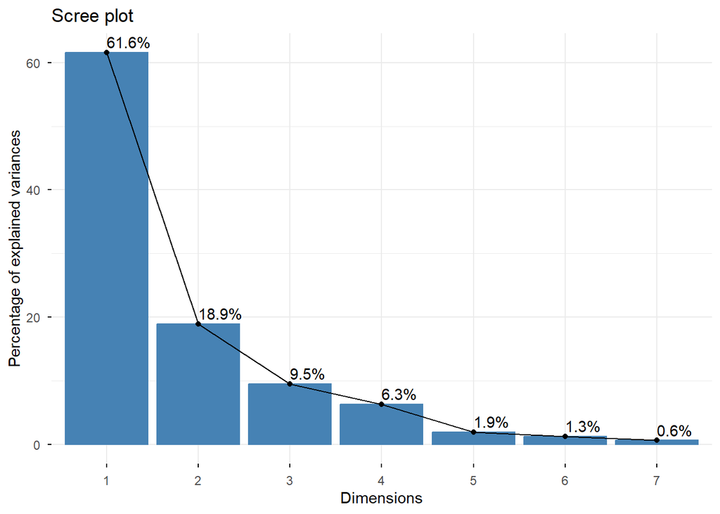

### Non-PCA Model Table

Non-PCA Linear Regression Table

| Model | MAE | RMSE | R² | Adjusted R² |
| --- | --- | --- | --- | --- |
| future_revenue ~ total_revenue | 1164.895 | 2173.488 | 79.70% | 75.80% |
| future_revenue ~ total_revenue+lag_revenue | 1121.393 | 2137.533 | 80.31% | 77.00% |
| future_revenue ~ total_revenue+lag_revenue+total_sellers | 1138.931 | 2307.118 | 77.00% | 78.80% |
| future_revenue ~ total_revenue+lag_revenue+total_sellers+avg_reviews | 1139.113 | 2307.200 | 77.00% | 78.80% |
| future_revenue ~ total_revenue+lag_revenue+total_sellers+avg_reviews+late_proportion | 1140.634 | 2307.224 | 77.00% | 78.80% |
| future_revenue ~ total_revenue+lag_revenue+total_sellers+avg_reviews+late_proportion+rolling_sd4 | 1141.554 | 2292.898 | 77.29% | 78.90% |
| future_revenue ~ total_revenue+lag_revenue+total_sellers+avg_reviews+late_proportion+rolling_sd4+rolling_mean4 | 1086.977 | 2161.447 | 79.82% | 79.90% |

## Regression Tree

### The Table

Regression Tree Table

First 10 Observations

| Model | MAE | RMSE | R² | tree_depth | min_n | cost_complexity |
| --- | --- | --- | --- | --- | --- | --- |
| future_revenue ~ total_revenue+lag_revenue | 1168.330 | 2128.571 | 80.46% | 5 | 5 | 0.001 |
| future_revenue ~ total_revenue+lag_revenue | 1169.653 | 2139.168 | 80.29% | 5 | 2 | 0.001 |
| future_revenue ~ total_revenue+lag_revenue | 1172.812 | 2137.296 | 80.27% | 5 | 10 | 0.001 |
| future_revenue ~ total_revenue+lag_revenue | 1179.341 | 2149.693 | 80.26% | 8 | 5 | 0.001 |
| future_revenue ~ total_revenue+lag_revenue | 1166.824 | 2149.739 | 80.06% | 5 | 10 | 0.000 |
| future_revenue ~ total_revenue+lag_revenue | 1185.876 | 2160.127 | 80.05% | 8 | 10 | 0.001 |
| future_revenue ~ total_revenue+lag_revenue | 1180.796 | 2167.900 | 79.99% | 10 | 2 | 0.001 |
| future_revenue ~ total_revenue+lag_revenue | 1169.906 | 2156.860 | 79.94% | 5 | 5 | 0.000 |
| future_revenue ~ total_revenue+lag_revenue | 1166.490 | 2158.125 | 79.94% | 5 | 2 | 0.000 |
| future_revenue ~ total_revenue+lag_revenue | 1191.821 | 2172.874 | 79.87% | 10 | 10 | 0.001 |

### Tree Plot

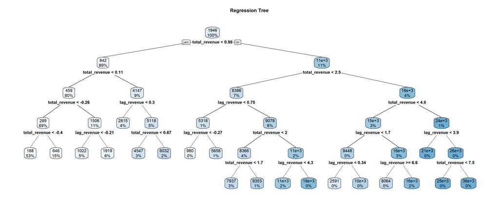

## Random Forest

### Top 5 Random Forest Results Table

Top 5 Random Forest Results

| Model | MAE | RMSE | R² | trees | mtry | min_n |
| --- | --- | --- | --- | --- | --- | --- |
| future_revenue ~ total_revenue+lag_revenue | 1122.263 | 2099.074 | 80.98% | 500 | 1 | 20 |
| future_revenue ~ total_revenue+lag_revenue | 1123.054 | 2105.103 | 80.88% | 750 | 1 | 20 |
| future_revenue ~ total_revenue+lag_revenue | 1121.983 | 2106.414 | 80.86% | 1000 | 1 | 20 |
| future_revenue ~ total_revenue+lag_revenue | 1135.355 | 2112.262 | 80.85% | 500 | 2 | 20 |
| future_revenue ~ total_revenue+lag_revenue | 1135.024 | 2112.825 | 80.83% | 750 | 2 | 20 |